# Credit scoring:

Author

ZHANG Hanrui

- For **individuals** (*credit scoring*), this usually encompasses: age, gender, income, wealth, job type, payment history (prior defaults), etc.

```r
#install.packages("tidyverse")
#install.packages(c("tidymodels", "randomForest", "doParallel", "torch", "caTools", "tabnet", "lime", "luz"))
#install.packages("caret")
```

# Data

```r
library(tidyverse)                           # Data wrangling
library(tidymodels)                          # ML workflow
library(caret)
load("bankruptcy.RData")
dim(bankruptcy) # Load data
```

```
[1] 6819   96
```

```r
names(bankruptcy)[1] <- "Bankrupt"
names(bankruptcy) <- gsub(" ", "_", names(bankruptcy))
colnames(bankruptcy)
```

```
 [1] "Bankrupt"
 [2] "ROA(C)_before_interest_and_depreciation_before_interest"
 [3] "ROA(A)_before_interest_and_%_after_tax"
 [4] "ROA(B)_before_interest_and_depreciation_after_tax"
 [5] "Operating_Gross_Margin"
 [6] "Realized_Sales_Gross_Margin"
 [7] "Operating_Profit_Rate"
 [8] "Pre-tax_net_Interest_Rate"
 [9] "After-tax_net_Interest_Rate"
[10] "Non-industry_income_and_expenditure/revenue"
[11] "Continuous_interest_rate_(after_tax)"
[12] "Operating_Expense_Rate"
[13] "Research_and_development_expense_rate"
[14] "Cash_flow_rate"
[15] "Interest-bearing_debt_interest_rate"
```

[output cut: 81 more lines]

have a look at missing data

```r
sum(is.na(bankruptcy))
```

```
[1] 0
```

This in no missing value in our bankruptcy dataset. Let’s check the type of each column:

```r
str(bankruptcy)
```

```
spc_tbl_ [6,819 × 96] (S3: spec_tbl_df/tbl_df/tbl/data.frame)
 $ Bankrupt                                               : num [1:6819] 1 1 1 1 1 1 0 0 0 0 ...
 $ ROA(C)_before_interest_and_depreciation_before_interest: num [1:6819] 0.371 0.464 0.426 0.4 0.465 ...
 $ ROA(A)_before_interest_and_%_after_tax                 : num [1:6819] 0.424 0.538 0.499 0.451 0.538 ...
 $ ROA(B)_before_interest_and_depreciation_after_tax      : num [1:6819] 0.406 0.517 0.472 0.458 0.522 ...
 $ Operating_Gross_Margin                                 : num [1:6819] 0.601 0.61 0.601 0.584 0.599 ...
 $ Realized_Sales_Gross_Margin                            : num [1:6819] 0.601 0.61 0.601 0.584 0.599 ...
 $ Operating_Profit_Rate                                  : num [1:6819] 0.999 0.999 0.999 0.999 0.999 ...
 $ Pre-tax_net_Interest_Rate                              : num [1:6819] 0.797 0.797 0.796 0.797 0.797 ...
 $ After-tax_net_Interest_Rate                            : num [1:6819] 0.809 0.809 0.808 0.809 0.809 ...
 $ Non-industry_income_and_expenditure/revenue            : num [1:6819] 0.303 0.304 0.302 0.303 0.303 ...
 $ Continuous_interest_rate_(after_tax)                   : num [1:6819] 0.781 0.782 0.78 0.781 0.782 ...
 $ Operating_Expense_Rate                                 : num [1:6819] 1.26e-04 2.90e-04 2.36e-04 1.08e-04 7.89e+09 ...
 $ Research_and_development_expense_rate                  : num [1:6819] 0.00 0.00 2.55e+07 0.00 0.00 0.00 7.30e+08 5.09e+07 0.00 0.00 ...
 $ Cash_flow_rate                                         : num [1:6819] 0.458 0.462 0.459 0.466 0.463 ...
 $ Interest-bearing_debt_interest_rate                    : num [1:6819] 0.000725 0.000647 0.00079 0.000449 0.000686 ...
 $ Tax_rate_(A)                                           : num [1:6819] 0 0 0 0 0 ...
 $ Net_Value_Per_Share_(B)                                : num [1:6819] 0.148 0.182 0.178 0.154 0.168 ...
 $ Net_Value_Per_Share_(A)                                : num [1:6819] 0.148 0.182 0.178 0.154 0.168 ...
 $ Net_Value_Per_Share_(C)                                : num [1:6819] 0.148 0.182 0.194 0.154 0.168 ...
 $ Persistent_EPS_in_the_Last_Four_Seasons                : num [1:6819] 0.169 0.209 0.181 0.194 0.213 ...
 $ Cash_Flow_Per_Share                                    : num [1:6819] 0.312 0.318 0.307 0.322 0.319 ...
 $ Revenue_Per_Share_(Yuan_¥)                             : num [1:6819] 0.01756 0.02114 0.00594 0.01437 0.02969 ...
 $ Operating_Profit_Per_Share_(Yuan_¥)                    : num [1:6819] 0.0959 0.0937 0.0923 0.0778 0.0969 ...
 $ Per_Share_Net_profit_before_tax_(Yuan_¥)               : num [1:6819] 0.139 0.17 0.143 0.149 0.168 ...
 $ Realized_Sales_Gross_Profit_Growth_Rate                : num [1:6819] 0.0221 0.0221 0.0228 0.022 0.0221 ...
 $ Operating_Profit_Growth_Rate                           : num [1:6819] 0.848 0.848 0.848 0.848 0.848 ...
 $ After-tax_Net_Profit_Growth_Rate                       : num [1:6819] 0.689 0.69 0.689 0.689 0.69 ...
 $ Regular_Net_Profit_Growth_Rate                         : num [1:6819] 0.689 0.69 0.689 0.689 0.69 ...
 $ Continuous_Net_Profit_Growth_Rate                      : num [1:6819] 0.218 0.218 0.218 0.218 0.218 ...
 $ Total_Asset_Growth_Rate                                : num [1:6819] 4.98e+09 6.11e+09 7.28e+09 4.88e+09 5.51e+09 6.08e+08 5.72e+09 6.63e+09 6.89e+09 5.55e+09 ...
 $ Net_Value_Growth_Rate                                  : num [1:6819] 0.000327 0.000443 0.000396 0.000382 0.000439 ...
 $ Total_Asset_Return_Growth_Rate_Ratio                   : num [1:6819] 0.263 0.265 0.264 0.263 0.265 ...
 $ Cash_Reinvestment_%                                    : num [1:6819] 0.364 0.377 0.369 0.384 0.38 ...
 $ Current_Ratio                                          : num [1:6819] 0.00226 0.00602 0.01154 0.00419 0.00602 ...
 $ Quick_Ratio                                            : num [1:6819] 0.00121 0.00404 0.00535 0.0029 0.00373 ...
 $ Interest_Expense_Ratio                                 : num [1:6819] 0.63 0.635 0.63 0.63 0.636 ...
 $ Total_debt/Total_net_worth                             : num [1:6819] 0.02127 0.0125 0.02125 0.00957 0.00515 ...
 $ Debt_ratio_%                                           : num [1:6819] 0.208 0.171 0.208 0.151 0.107 ...
 $ Net_worth/Assets                                       : num [1:6819] 0.792 0.829 0.792 0.849 0.893 ...
```

[output cut: 142 more lines]

```
  ..   `Cash Flow to Equity` = col_double(),
  ..   `Current Liability to Current Assets` = col_double(),
  ..   `Liability-Assets Flag` = col_double(),
  ..   `Net Income to Total Assets` = col_double(),
  ..   `Total assets to GNP price` = col_double(),
  ..   `No-credit Interval` = col_double(),
  ..   `Gross Profit to Sales` = col_double(),
  ..   `Net Income to Stockholder's Equity` = col_double(),
  ..   `Liability to Equity` = col_double(),
  ..   `Degree of Financial Leverage (DFL)` = col_double(),
  ..   `Interest Coverage Ratio (Interest expense to EBIT)` = col_double(),
  ..   `Net Income Flag` = col_double(),
  ..   `Equity to Liability` = col_double()
  .. )
 - attr(*, "problems")=<externalptr>
```

Our data are in numerical format.

```r
data <- bankruptcy |>
  na.omit() |>                # Remove rows with missing points
  mutate(Bankrupt = as.factor(Bankrupt),    # Categorize (for classification)
         across(where(is.character), as.factor))
data |> head()
```

| Bankrupt | ROA(C)_before_interest_and_depreciation_before_interest | ROA(A)*before_interest_and*%_after_tax | ROA(B)_before_interest_and_depreciation_after_tax | Operating_Gross_Margin | Realized_Sales_Gross_Margin | Operating_Profit_Rate | Pre-tax_net_Interest_Rate | After-tax_net_Interest_Rate | Non-industry_income_and_expenditure/revenue | Continuous_interest_rate_(after_tax) | Operating_Expense_Rate | Research_and_development_expense_rate | Cash_flow_rate | Interest-bearing_debt_interest_rate | Tax_rate_(A) | Net_Value_Per_Share_(B) | Net_Value_Per_Share_(A) | Net_Value_Per_Share_(C) | Persistent_EPS_in_the_Last_Four_Seasons | Cash_Flow_Per_Share | Revenue_Per_Share_(Yuan_¥) | Operating_Profit_Per_Share_(Yuan_¥) | Per_Share_Net_profit_before_tax_(Yuan_¥) | Realized_Sales_Gross_Profit_Growth_Rate | Operating_Profit_Growth_Rate | After-tax_Net_Profit_Growth_Rate | Regular_Net_Profit_Growth_Rate | Continuous_Net_Profit_Growth_Rate | Total_Asset_Growth_Rate | … |
| --- | --- | --- | --- | --- | --- | --- | --- | --- | --- | --- | --- | --- | --- | --- | --- | --- | --- | --- | --- | --- | --- | --- | --- | --- | --- | --- | --- | --- | --- | --- |
| 1 | 0.3705943 | 0.4243894 | 0.4057498 | 0.6014572 | 0.6014572 | 0.9989692 | 0.7968871 | 0.8088094 | 0.3026464 | 0.7809849 | 1.257e-04 | 0 | 0.4581431 | 0.0007251 | 0 | 0.1479499 | 0.1479499 | 0.1479499 | 0.1691406 | 0.3116644 | 0.0175598 | 0.0959205 | 0.1387362 | 0.0221023 | 0.8481950 | 0.6889795 | 0.6889795 | 0.2175354 | 4.98e+09 | … |
| 1 | 0.4642909 | 0.5382141 | 0.5167300 | 0.6102351 | 0.6102351 | 0.9989460 | 0.7973802 | 0.8093007 | 0.3035564 | 0.7815060 | 2.898e-04 | 0 | 0.4618673 | 0.0006471 | 0 | 0.1822511 | 0.1822511 | 0.1822511 | 0.2089439 | 0.3181368 | 0.0211443 | 0.0937220 | 0.1699179 | 0.0220802 | 0.8480879 | 0.6896929 | 0.6897017 | 0.2176196 | 6.11e+09 | … |
| 1 | 0.4260713 | 0.4990188 | 0.4722951 | 0.6014500 | 0.6013635 | 0.9988574 | 0.7964034 | 0.8083875 | 0.3020352 | 0.7802839 | 2.361e-04 | 25500000 | 0.4585206 | 0.0007901 | 0 | 0.1779107 | 0.1779107 | 0.1937129 | 0.1805805 | 0.3071019 | 0.0059440 | 0.0923378 | 0.1428033 | 0.0227601 | 0.8480940 | 0.6894627 | 0.6894697 | 0.2176013 | 7.28e+09 | … |
| 1 | 0.3998440 | 0.4512647 | 0.4577333 | 0.5835411 | 0.5835411 | 0.9986997 | 0.7969670 | 0.8089656 | 0.3033495 | 0.7812410 | 1.079e-04 | 0 | 0.4657054 | 0.0004490 | 0 | 0.1541865 | 0.1541865 | 0.1541865 | 0.1937222 | 0.3216736 | 0.0143685 | 0.0777624 | 0.1486028 | 0.0220461 | 0.8480055 | 0.6891095 | 0.6891095 | 0.2175682 | 4.88e+09 | … |
| 1 | 0.4650222 | 0.5384322 | 0.5222978 | 0.5987835 | 0.5987835 | 0.9989731 | 0.7973661 | 0.8093037 | 0.3034750 | 0.7815500 | 7.890e+09 | 0 | 0.4627463 | 0.0006861 | 0 | 0.1675024 | 0.1675024 | 0.1675024 | 0.2125366 | 0.3191625 | 0.0296898 | 0.0968976 | 0.1684115 | 0.0220959 | 0.8482582 | 0.6896969 | 0.6896969 | 0.2176256 | 5.51e+09 | … |
| 1 | 0.3886803 | 0.4151766 | 0.4191338 | 0.5901714 | 0.5902507 | 0.9987581 | 0.7969032 | 0.8087706 | 0.3031158 | 0.7810691 | 1.571e-04 | 0 | 0.4658615 | 0.0007161 | 0 | 0.1555771 | 0.1555771 | 0.1555771 | 0.1744351 | 0.3253873 | 0.0181043 | 0.0780881 | 0.1388115 | 0.0215649 | 0.8479828 | 0.6891051 | 0.6891775 | 0.2175664 | 6.08e+08 | … |

# Pivot table practice

```r
data |>
  group_by(Bankrupt) |>
  summarise(avg_Operating_Profit_Rate = mean(Operating_Profit_Rate)|> round(4),
            avg_Gross_Profit_to_Sales = mean(Gross_Profit_to_Sales)|> round(2))
```

| Bankrupt | avg_Operating_Profit_Rate | avg_Gross_Profit_to_Sales |
| --- | --- | --- |
| 0 | 0.9988 | 0.61 |
| 1 | 0.9987 | 0.60 |

# Check the our sample frequency

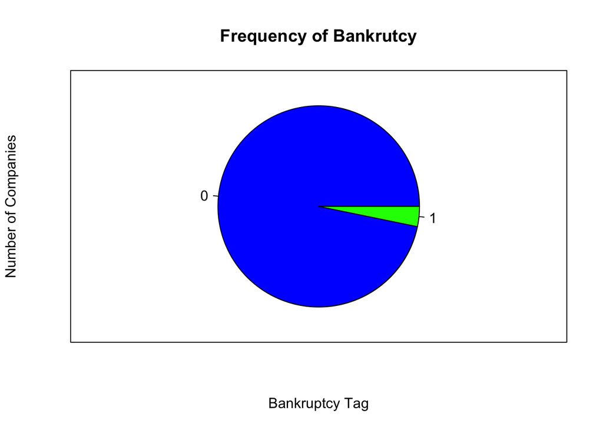

```r
library(ggplot2)
pie(table(data[1]),
       main="Frequency of Bankrutcy",
       xlab="Bankruptcy Tag",
       ylab="Number of Companies",
       col= c("blue", "green"))
box()
```

Identify columns in the bankruptcy data frame that have no variability: -If have one we need to delete it because it’s not useful, no information. -All the data in this column are same

```r
which(apply(data, 2, var)==0)
```

```
Net_Income_Flag
             95
```

So we need to remove this column which just contained one value “1”.

```r
data <- subset(data, select = -Net_Income_Flag)
```

# Baseline learning

## Preparation

As is usual in machine learning, we will split the data in two part - train / test -cross validation with 5 folds : help us to train a more stable model

```r
data_split <- initial_split(data, prop = 0.75) # 0.5 to save time on training...
data_train <- training(data_split) |> vfold_cv(v = 5) # Creates the folds
data_test <- testing(data_split)
```

## Model Pipeline

```r
library(randomForest)             # Just in case...
rf_model <-                       # Here we define the model
  rand_forest(
    mtry = tune(),            # The hyperparameters will be tuned!
    trees = tune()
  ) |>
  set_engine("randomForest") |> # I use randomForest to train my model
  set_mode("classification")    # Classification problem (1/0)
```

## hyperparameters metric

```r
rf_grid <- grid_regular(mtry(range = c(10, 20)),  # There are dedicated function for parameters!
                        trees(range = c(5, 20)),  # Small numbers to reduce CPU time
                        levels = c(2,3))          # 2 & 3 choices for 1st and 2nd parameters
rf_grid
```

| mtry | trees |
| --- | --- |
| 10 | 5 |
| 20 | 5 |
| 10 | 12 |
| 20 | 12 |
| 10 | 20 |
| 20 | 20 |

## WorkFlow

```r
set.seed(42)
rf_wf <- workflow() |>
  add_model(rf_model) |>
  add_formula(Bankrupt ~ .)  # This means we predict Bankrupt with all other variables
```

Here I do the parallel to reduce the training time :

```r
library(doParallel)
doParallel::registerDoParallel(6)        # Specifies the number of cores
rf_res <- rf_wf |>
  tune_grid(                             # This will train on all params
    resamples = data_train,
    grid = rf_grid
  )
show_best(rf_res, metric = "accuracy")   # Shows the best params
```

| mtry | trees | .metric | .estimator | mean | n | std_err | .config |
| --- | --- | --- | --- | --- | --- | --- | --- |
| 20 | 20 | accuracy | binary | 0.9710598 | 5 | 0.0014371 | Preprocessor1_Model6 |
| 20 | 12 | accuracy | binary | 0.9685169 | 5 | 0.0022199 | Preprocessor1_Model4 |
| 10 | 20 | accuracy | binary | 0.9667579 | 5 | 0.0018803 | Preprocessor1_Model5 |
| 10 | 12 | accuracy | binary | 0.9651933 | 5 | 0.0022430 | Preprocessor1_Model3 |
| 10 | 5 | accuracy | binary | 0.9634338 | 5 | 0.0022838 | Preprocessor1_Model1 |

The average accuracy rate is high, but as we have an extremely imbalanced dataset, there might be overfitting.

```r
mean(data$Bankrupt |> as.character() |> as.numeric() == 0)
```

```
[1] 0.9677372
```

if we predict 0 each time, we would be correct 96% of the time.So we can’t say our model has high accuracy honestily.